# Introdução à Ciência de Dados

Mestrado Profissional em Administração

Prof. Washington Santos da Silva

IFMG - Campus Formiga

17 de julho de 2025

## Diário de Bordo

**O que vimos até aqui?**

- Aula 1 ✅
  - Apresentação da Disciplina ✅
  - Introdução e Contextualização ✅
  - O que é Ciência de Dados? ✅
  - Pesquisa Reproduzível e Ciência de Dados ✅
  - Papéis Profissionais ✅
  - Aplicações ✅
  - Habilidades Interpessoais e Analíticas ✅
  - Apresentação da Disciplina ✅
  - Configurações: Git/GitHub ✅
- Aula 2 ✅
  - Metodologia CRISP-DM ✅
  - Tipos de Análise de Dados ✅
  - Introdução ao RStudio e criação do **seu** Projeto da Disciplina ✅
  - Introdução ao Sistema de Publicação Quarto ✅
  - Introdução ao Git e GitHub: controle de versão e criação do **seu** repositório no GitHub ✅
- Aula 3 ✅
  - Breve Revisão sobre o RStudio ✅
  - Sistema de Publicação Quarto: (Cont.) ✅
  - Introdução ao Git e GitHub: (Cont.) ✅
  - Sessão Prática: Fluxo de trabalho integrando RStudio/Quarto/R/Git/GitHub ✅
- Aula 4 ✅
  - Conceitos de Variáveis e Observações em Estatística ✅
  - Conceito de Dados Organizados (*Tidy Data*) ✅
  - Tipos atômicos e classes principais de dados da linguagem R ✅
  - Tipos de Dados Tradicionais em Finanças: ✅
    - Dados em Secção-Cruzada (ou Transversal) (*Cross-Section Data*) ✅
    - Dados em Secções-Cruzadas Combinadas (*Pooled Cross-Section Data*) ✅
    - Dados em Séries Temporais (*Time Series Data*) ✅
    - Dados em Painel (ou Longitudinais) (*Panel Data*) ✅
  - Importação e Preparação de Dados Típicos de Finanças com exemplos práticos ✅
- Aula 5 ✅
  - Metodologia CRISP-DM: Fases 2 e 3 ✅
  - Revisão sobre Dados Organizados (*Tidy Data*) ✅
  - Introdução ao Pacote tidyr: função pivot_longer() ✅
  - Introdução ao Pacote dplyr: funções select() e filter() ✅
  - Exercícios ✅
- Aula 6 ✅
  - Função mutate ✅
  - Funções group_by e summarize ✅
  - Exercícios ✅
- Aula 7 ✅
  - Introdução ao Pacote dplyr: Tipos Básicos de *joins* ✅
  - Exercícios ✅
- Aula 8 ✅
  - Avaliação 1
- Aula 9 ✅
  - Modelos ✅
  - Conceitos Fundamentais de Probabilidade ✅
    - O que é Probabilidade? ✅
    - Probabilidade Condicional e Independência ✅
    - Amostra Aleatória ✅
    - Variáveis Aleatórias e Funções de Probabilidade ✅
    - Função de Distribuição Acumulada ✅
    - Lei dos Grandes Números ✅
  - Distribuições de Probabilidade de VA Discretas ✅
    - Distribuição de Bernoulli ✅
    - Características de uma Distribuição de Probabilidade ✅
      - Valor Esperado ✅
      - Variância e Desvio-Padrão ✅
      - Assimetria e Curtose ✅
  - Distribuição Binomial ✅
- Aula 10 ✅
  - Distribuições de Probabilidade de VA Contínuas ✅
    - Distribuição Uniforme ✅
    - Método da Transformação Invesa da FDA ✅
    - Distribuição Normal ✅
    - Teorema Central do Limite ✅
    - Fundamentos de Simulação de Monte Carlo ✅
    - Distribuição Conjunta de Variáveis Aleatórias ✅
    - Distribuição Condicional ✅
    - Distribuição Marginal ✅
    - Independência de Variáveis Aleatórias ✅
    - Covariância e Correlação ✅
- Aula 11 ✅
  - Simulação de Monte Carlo - Aplicações ✅
  - Aplicação - Valor-em-Risco (VaR) ✅
    - Pacote tidyquant, Séries de Preços e de Rretornos de Acões ✅
    - Método Paramétrico ✅
    - Método Histórico ✅
    - Método de Simulação de Monte Carlo ✅
  - Aplicação - ES/CVaR ✅
- Aula 12 ✅
  - Revisão de Matemática Básica ✅
  - Estatística, Probabilidade e Simulação ✅
  - Parâmetro, Estimador/Estatística, Estimativa ✅
  - Métodos de Inferência Estatística ✅
  - Estimação Pontual de Parâmetros Populacionais ✅
    - Método da Máxima Verossimilhança ✅
    - Propriedades de Estimadores ✅
- Aula 13 ✅
  - Método da Máxima Verossimilhança ✅
    - Informação de Fisher ✅
  - Testes de Hipóteses ✅
  - Distribuição Amostral ✅
  - Estimação por Intervalo de Confiança ✅
    - Método da Quantidade Pivotal ✅

## Nesta Aula

**Tópicos - Fundamentos de Estatística e Simulação**

- Testes de Significância
  - Conceitos Fundamentais
  - Interpretações corretas e abusos
  - Tamanho de Efeito
  - Análise de Poder e Tamanho da Amostra

**Diretrizes para Aulas Mais Produtivas**

⌨️ **Código com método:**

95% dos erros são evitáveis com:

- Atenção na digitação
- Respeitar a sequência lógica de etapas
- Revisão antes de pedir ajuda

🤝 **Inteligência colaborativa:**

- Compartilhe conhecimento
- Resolva questões técnicas simples com colegas próximos
- Reserve ao professor as dúvidas conceituais complexas

💪 **Capacidade de Resolver Problemas**

Cada erro resolvido é uma evolução da sua habilidade analítica

## Fundamentos de Inferência Estatística

**Descrição**

Inferência estatística são métodos que consistem em usar dados de uma amostra para tirar conclusões sobre parâmetros de uma população subjacente da qual a amostra foi retirada.

**Métodos da Escola Frequentista/Máxima Verossimilhança**

- Estimação de Parâmetros:
  - Estimação Pontual ✓
  - Estimação por Intervalo de Confiança ✓
- Testes de Significância (ou Testes Estatísticos de Hipóteses)

# Testes de Significância

## Testes de Significância

**Hipóteses em Estatística e Econometria**

- Em Estatística/Econometria, uma hipótese é uma **declaração** sobre um **parâmetro populacional**, isto é, uma característica (como média, variância ou coeficiente de um modelo) da **distribuição** de probabilidade que rege a **variável de interesse.**
- A hipótese assume a forma de uma **previsão sobre o valor de um parâmetro** (ou sobre a relação entre parâmetros) **da distribuição da população de interesse**. que pode ser testada com base em dados amostrais.
- Em geral, as hipóteses são derivadas de teorias ou modelos econômicos e financeiros.

## Testes de Significância

**Exemplos de Hipóteses em Finanças**

- **Hipótese:** A **rentabilidade média** sobre o ativo (ROA) das cooperativas de crédito que adotaram práticas recomendadas de governança corporativa é significativamente maior do que a rentabilidade média das cooperativas que não adotaram tais práticas.
- **Hipótese:** A **taxa média de juros efetiva** obtida por empresas do agronegócio brasileiro que reportam indicadores de desempenho ambiental (ESG) é significativamente menor do que a taxa média de juros das empresas do setor que não reportam tais indicadores.

## Testes de Significância

**Hipóteses em Finanças**

- **Hipótese:** A **alavancagem financeira** exerce efeito significativo sobre o valor de mercado das empresas.
- **Parâmetro populacional envolvido:** o coeficiente $\beta$ da variável “alavancagem financeira” em um **modelo de regressão linear** que explica o valor de mercado da empresa ($Y_i$) com base em variáveis como alavancagem ($X_1$), lucratividade ($X_2$), tamanho ($X_3$) e setor ($X_4$).
- A hipótese testa se $\beta_1 \neq 0$ (coeficiente associada à variável alavancagem), ou seja, se há efeito sistemático da alavancagem sobre o valor da firma.

$$Y_i = \beta_0 + \beta_1 X_{1i} + \beta_2 X_{2i} + \beta_3 X_{3i} + \beta_4 X_{4i} + \epsilon_i,\quad \epsilon_i \sim N(0,\sigma^2)$$

onde $Y_i$ representa o valor de mercado da empresa *i*, e os $X_{ji}$ são as variáveis explicativas (alavancagem, lucratividade, tamanho e setor).

## Tríade da Inferência Estatística Moderna (Escola Frequentista)

**Estimativa, Teste de Significância e Tamanho de Efeito**

#### **Estimativas Pontuais e Intervalar**

- Produz uma **estimativa pontual** (ex.: média amostral, coeficiente estimado) do parâmetro populacional.
- Acompanhada de um **intervalo de confiança** (IC), que expressa a **incerteza associada** à estimativa devido à variabilidade amostral.

#### **Teste de Significância**

- Testa se os dados fornecem evidência contra ou a favor da **hipótese nula** usando uma estatística de teste.
- O **valor‑p** representa a probabilidade de obter um resultado tão extremo quanto o observado, **assumindo que a hipótese nula seja verdadeira**.
- Informa a significância **estatística**, mas **não** mede a significância **prática**.

#### **Tamanho do Efeito**

- Mede a **magnitude e a direção do efeito** observado.
- Indica **relevância prática** (ex.: diferença de médias, coeficiente padronizado, $R^2$, elasticidade).
- Um efeito pode ser estatisticamente significativo, mas ainda assim **irrelevante** do ponto de vista substantivo.
- Relatórios científicos **robustos** devem interpretar conjuntamente os três elementos: estimativa pontual com IC (confiabilidade), valor-p (significância estatística) e tamanho de efeito (relevância prática).

## Hipóteses Estatísticas

**Descrição**

- $H_0$ **(hipótese nula)**
  - Declaração formal sobre o parâmetro populacional.
  - Frequentemente assume a forma de **igualdade** (ex.: $\mu_1 = \mu_2$, $\beta = 0$), representando **ausência de** **efeito**, associação ou diferença.
  - Pode, em certos testes, assumir forma de **desigualdade** (ex.: $\sigma^2 \leq \sigma_0^2$, $\rho \geq 0$).
  - É a hipótese a ser testada com os dados — **não é aquilo que se deseja verificar**, mas sim **o ponto de partida a ser potencialmente refutado**.
- $H_A$ (ou $H_1$) **(hipótese alternativa)**
  - Representa o efeito, associação ou diferença **que se deseja investigar ou demonstrar**.
  - Três formatos clássicos:
    - **Bilateral (duas caudas):** $H_A: \theta \neq \theta_0$
    - **Unilateral à direita:** $H_A: \theta > \theta_0$
    - **Unilateral à esquerda:** $H_A: \theta < \theta_0$

## Hipóteses Estatísticas

**Exemplos formais**

1. **Comparação de médias (unilateral):**

$$\begin{cases}
H_0 : \mu_A = \mu_B \\
H_A : \mu_A > \mu_B \quad \text{(ex.: incentivo monetário aumenta produtividade)}
\end{cases}$$

2. **Diferença de proporções (bilateral):**

$$\begin{cases}
H_0 : p_1 = p_2 \\
H_A : p_1 \neq p_2 \quad \text{(ex.: uso de hedge difere entre setores)}
\end{cases}$$

3. **Coeficiente em regressão linear (bilateral):**

$$\begin{cases}
H_0 : \beta_1 = 0 \\
H_A : \beta_1 \neq 0 \quad \text{(ex.: ESG afeta taxa de juros efetiva)}
\end{cases}$$

4. **Teste unilateral sobre variância (menos comum, mas válido):**

$$\begin{cases}
H_0 : \sigma^2 \leq \sigma_0^2 \\
H_A : \sigma^2 > \sigma_0^2 \quad \text{(ex.: maior volatilidade após evento de mercado)}
\end{cases}$$

**Nota:** A escolha entre teste unilateral e bilateral deve ser justificada com base na teoria ou no contexto empírico.

## Métodos de Construção de Testes de Hipóteses

**Abordagens Fundamentais**

1. **Teste baseado em estatística de teste com distribuição amostral conhecida sob $H_0$**
   - Ex.: teste t, z, F, qui-quadrado.
- Compara a estatística observada com sua distribuição sob $H_0$; calcula-se o valor‑p.
3. **Teste de Wald**
   - Usa a estimativa do parâmetro e sua variância para testar $H_0$.
   - Simples de implementar; requer apenas o modelo irrestrito.
   - Ex.: coeficientes em regressão linear ou logística.
4. **Teste da razão de verossimilhanças (LRT)**
   - Compara dois modelos: um com as restrições de $H_0$, outro sem.
   - A estatística de teste segue uma distribuição qui-quadrado assintótica.
   - Ampla aplicação em modelos de regressão generalizada (GLM, Logit, Poisson…).
5. **Teste do Multiplicador de Lagrange**
   - Avalia se o **gradiente da função de log-verossimilhança** (score) sob $H_0$ difere significativamente de zero.
   - Requer apenas a estimação do modelo com restrições.
   - Útil quando o modelo irrestrito é difícil de estimar.
6. **Teste bootstrap (não paramétrico)**
   - Reamostragem da amostra para simular a distribuição da estatística sob $H_0$.
   - Útil quando não se pode assumir normalidade ou forma funcional exata da distribuição.
- **Nota:** Wald, LRT e Score são assintoticamente equivalentes sob condições regulares, mas diferem em aplicabilidade prática e robustez.

## Testes Wald, LRT e Score

**Descrição**

#### **Teste de Wald**

Avalia se um parâmetro $\theta$ (ou vetor $\boldsymbol{\theta}$) difere significativamente de um valor sob $H_0$, com base na **estimativa sob o modelo irrestrito**.

Formulação geral:

Seja $\hat{\theta}$ o estimador de máxima verossimilhança de $\theta$ e $\text{Var}(\hat{\theta})$ sua matriz de variância-covariância:

$$W = \frac{(\hat{\theta} - \theta_0)^2}{V(\hat{\theta})} \quad \text{ou, no caso vetorial:} \quad W = (\hat{\theta} - \theta_0)' \cdot \left[V(\hat{\theta}) \right]^{-1} \cdot (\hat{\theta} - \theta_0)$$

Sob $H_0$, $W \overset{a}{\sim} \chi^2_q$, onde $q$ é o número de restrições.

#### **Teste da Razão de Verossimilhança (LRT)**

Compara o ajuste de dois modelos:

- Um modelo **restrito** (sob $H_0$);
- Um modelo **irrestrito** (sem restrições).

Estatística:

$$LR = -2 \left[ \log L_R - \log L_U \right]$$

- $\mathcal{L}_R$: log-verossimilhança do modelo **restrito**
- $\mathcal{L}_U$: log-verossimilhança do modelo **irrestrito**
- Sob $H_0$, $LR \overset{a}{\sim} \chi^2_q$, com $q$ restrições testadas.

#### **Teste do Multiplicador de Lagrange**

Avalia se o **gradiente da função de log-verossimilhança** (vetor escore) é zero sob $H_0$, sem precisar estimar o modelo irrestrito.

Estatística:

$$S = \mathbf{U}(\theta_0)' \cdot \left[ I(\theta_0) \right]^{-1} \cdot \mathbf{U}(\theta_0)$$

- $\mathbf{U}(\theta_0) = \frac{\partial \log \mathcal{L}(\theta)}{\partial \theta} \Big|_{\theta = \theta_0}$: vetor escore
- $I(\theta_0)$: matriz de informação de Fisher (esperada) sob $H_0$
- Sob $H_0$, $S \overset{a}{\sim} \chi^2_q$

#### **Equivalência assintótica**

Sob determinadas condições e para grandes amostras:

$$W \approx LR \approx S \sim \chi^2_q$$

#### Quando preferir cada um?

- **Wald**: quando o modelo irrestrito já está ajustado e os parâmetros são bem comportados (não no limite do espaço paramétrico).
- **LRT**: quando ambos os modelos são estimáveis e se deseja robustez e boa performance.
- **Multiplicador de Lagrange**: quando o modelo irrestrito é difícil ou computacionalmente difícil de estimar.

## Teste t de Welch

**Teste t de Welch**

- Demonstração de que a **distribuição amostral** da estatística de teste para a comparação de duas médias é uma distibuição $\approx$ t-Student para o caso de duas amostras independentes, ou seja, a base teórica do **teste t de Welch**, que é o caso mais geral na comparação entre médias.

#### Contexto

Queremos testar:

$$\begin{cases}
H_0 : \mu_1 = \mu_2 \\
H_A : \mu_1 \neq \mu_2
\end{cases}$$

com base em **duas amostras independentes**:

- $X_1, \dots, X_{n_1} \overset{iid}{\sim} N(\mu_1, \sigma_1^2)$
- $Y_1, \dots, Y_{n_2} \overset{iid}{\sim} N(\mu_2, \sigma_2^2)$

**Importante:** variâncias podem ser diferentes e desconhecidas → usamos o teste t de Welch.

#### 1. **Diferença Média Amostral**

Seja:

$$\bar{X} = \frac{1}{n_1} \sum X_i, \quad \bar{Y} = \frac{1}{n_2} \sum Y_j$$

Pela independência:

$$\bar{X} - \bar{Y} \sim N(\mu_1 - \mu_2,\ \frac{\sigma_1^2}{n_1} + \frac{\sigma_2^2}{n_2})$$

#### 2. **Substituição da variância populacional pela amostral**

Como $\sigma_1^2, \sigma_2^2$ são **desconhecidas**, usamos:

$$S_1^2 = \frac{1}{n_1 - 1} \sum_{i=1}^{n_1} (X_i - \bar{X})^2,\quad
S_2^2 = \frac{1}{n_2 - 1} \sum_{j=1}^{n_2} (Y_j - \bar{Y})^2$$

e o **erro padrão estimado da diferença** é:

$$EP_{(\bar{X} - \bar{Y})} = \sqrt{ \frac{S_1^2}{n_1} + \frac{S_2^2}{n_2} }$$

#### 3. **Construção da estatística t de Welch**

$$T = \frac{ \bar{X} - \bar{Y} - (\mu_1 - \mu_2) }{ \sqrt{ \frac{S_1^2}{n_1} + \frac{S_2^2}{n_2} } }$$

Sob $H_0: \mu_1 = \mu_2$, isso se reduz a:

$$T = \frac{ \bar{X} - \bar{Y} }{ \sqrt{ \frac{S_1^2}{n_1} + \frac{S_2^2}{n_2} } }$$

#### 4. **Distribuição da estatística T**

A distribuição exata de $T$ é **complicada** porque:

- É uma razão entre uma variável normal e a raiz quadrada de uma combinação de duas variâncias amostrais;
- Essas variâncias podem ser **baseadas em diferentes amostras** e possuem **distribuições qui-quadrado independentes**, com $n_1 - 1$ e $n_2 - 1$ graus de liberdade, respectivamente.
- Portanto, $T$ não segue exatamente uma distribuição t com $n_1 + n_2 - 2$ graus de liberdade (como no caso com variâncias iguais), mas sim uma distribuição t **aproximada**, com **graus de liberdade efetivos** dados por **Welch–Satterthwaite**.

#### 5. **Fórmula dos graus de liberdade aproximados**

$$df = \frac{ \left( \frac{S_1^2}{n_1} + \frac{S_2^2}{n_2} \right)^2 }
{ \frac{ (S_1^2/n_1)^2 }{n_1 - 1} + \frac{ (S_2^2/n_2)^2 }{n_2 - 1} }$$

Essa fórmula:

- Considera a variância de cada termo separadamente;
- **Ajusta os graus de liberdade** para refletir o fato de que estamos combinando variâncias estimadas com amostras diferentes.

#### 6. **Conclusão**

- A estatística $T$ do teste t de Welch segue aproximadamente uma distribuição t, com graus de liberdade calculados pela fórmula de Welch–Satterthwaite, **porque a variância da diferença é estimada separadamente para cada grupo**, a partir de **amostras independentes** com distribuições qui-quadrado.

## Testes Básicos e Implementação em R

**Hipóteses, Teste e Função R**

| **$H_0$** | **$H_A$** | **Teste estatístico adequado** | **Função R** | **Exemplo aplicado em Finanças** |
| --- | --- | --- | --- | --- |
| $\mu_1 = \mu_2$ | $\mu_1 \neq \mu_2$, $\mu_1 > \mu_2$ | Teste t para duas médias (independentes) | `t.test(x, y)` | Comparar ROA entre cooperativas com e sem governança |
| $p_1 = p_2$ | $p_1 \neq p_2$, $p_1 > p_2$ | Teste z para duas proporções | `prop.test(x, n)` | Diferença no uso de hedge cambial entre dois setores |
| $\beta = 0$ | $\beta \neq 0$, $\beta > 0$ | Teste t sobre coeficiente em regressão linear | `summary(lm(...))` | Efeito de ESG sobre taxa de juros efetiva |
| $\sigma^2_1 = \sigma^2_2$ | $\sigma^2_1 \neq \sigma^2_2$ | Teste F para comparação de variâncias | `var.test(x, y)` | Diferença na volatilidade de retornos antes e depois de um evento |
| $\rho = 0$ | $\rho \neq 0$, $\rho > 0$ | Teste t para correlação | `cor.test(x, y)` | Correlação entre alavancagem e inadimplência |
| $\beta_1 = \beta_2 = \dots = \beta_k = 0$ | Algum $\beta_j \neq 0$ | Teste F (restrição conjunta em regressão) | `anova(lm(...))` | Testar significância conjunta de variáveis explicativas do valor da firma |

## Quatro elementos de qualquer teste

**Elementos essenciais**

1. **Suposições** (tipos dos dados, $n$ etc.)
2. **Hipóteses** $H_0$ e $H_A$
3. **Estatística de teste** $T(Y)$ e sua distribuição sob $H_0$
4. **Valor‑p** do teste

## Suposições do teste

**Descrição**

#### **Aleatorização**:

A maioria dos testes de significância pressupõe que a **coleta de dados empregou aleatorização**, como uma amostra aleatória simples ou um experimento aleatorizado.

#### **Tipo de dados**

Cada teste de significância se aplica a diferentes tipos de dados, que podem ser **numéricos** ou **categóricos**.

#### **Distribuição da População**:

Alguns testes de significância pressupõem que a variável tem distribuição populacional que pertence a uma família particular de distribuições de probabilidade, como a **distribuição normal** ou a **distribuição binomial**.

#### **Tamanho da amostra**:

Alguns testes de significância, como aqueles baseados no Teorema Central do Limite, são válidos somente quando o tamanho da amostra é suficientemente **grande**. Enquanto outros são válidos, ou tem bom desempenho, em **amostras pequenas**.

## Hipóteses

**Hipóteses Nula e Alternativa**

#### Hipótese Nula $H_0$

- A hipótese nula é geralmente conservadora, no sentido de que reflete o *status quo*. Assim, muitas vezes, a hipótese nula assume a forma “**não há diferença**” ou “**não há efeito**” ou “**não há relaçào**” entre os parâmetros.

#### Hipótese Alternativa $H_A$

- A hipótese alternativa reflete alguma suspeita sobre os valores que o parâmetro pode assumir. A $H_A$ assume uma forma que pode ser interpretada como “*há uma diferença*” ou “*há um efeito*”.

#### Observações

- As hipóteses são formuladas **antes** da análise dos dados.
- Os intervalos definidos pelas hipóteses devem ser **mutuamente exclusivos**.
- As hipóteses alternativas geralmente são hipóteses que o analista/pesquisador deseja verificar se os dados a suportam, ou não.

## Estatística de teste

**Descrição**

Distância entre a estimativa $\hat \theta$ e o valor postulado $\theta_0$ sob $H_0$, medida em número de erros-padrão (EP) da estimativa.

$$Z \;=\; \frac{\hat\theta - \theta_0}{\operatorname{EP}(\hat\theta)}$$
- Para isso, usamos a distribuição amostral da estatística de teste, sob a suposição de que $H_0$ é “verdadeira”. Quanto mais perto a estatística de teste estiver dos extremos da distribuição amostral na direção prevista por $H_A$, mais forte é a evidência contra $H_0$, e vice-versa.

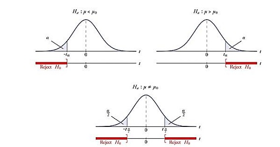

Estatística de Teste e Regiões de Rejeição e Não Rejeição da Hipótese nula

## Valor-p

**Definição**

- Podemos mensurar o quão distante a estatística de teste se encontra na extremidade da distribuição amostral pela probabilidade condicional de obter uma estatística de teste tão extrema quanto a observada, sob a suposição de que $H_0$ é “verdadeira”.

$$Z \;=\; \frac{\hat\theta - \theta_0}{\operatorname{EP}(\hat\theta)}
\qquad\Longrightarrow\qquad
\text{valor-p} \;=\; P_{H_0}\bigl(|Z| \ge |z_{\text{obs}}|\bigr)$$

- Essa probabilidade é chamada de **valor-p**.
- **Definição:** O valor-p é a probabilidade, supondo que $H_0$ seja “verdadeira”, de que a estatística de teste seja igual ou maior que o valor observado na direção prevista por $H_A$.
- Um **pequeno valor-p**, como 0,002, significa que é improvável obter uma estatística de teste como a obtida, se $H_0$ for verdadeira.
- Como um estatística de teste utiliza dos dados da amostra, podemos dizer, que um pequeno valor-p, como 0,002, signfica que os dados da amostra são improváveis de terem sido observados, se $H_0$ for “verdadeira”.
- **Um valor-p de moderado a grande**, como entre 0,26 e 0,83, significa que os dados são consistentes com $H_0$; Ou seja, os dados observados são bastante prováveis, se $H_0$ for “verdadeira”.

## Cálculo do Valor‑p

**Teste t para Diferença de Médias (Welch)**

#### **Hipóteses:**

$$\begin{cases}
H_0: \mu_1 = \mu_2 \\
H_A: \mu_1 \neq \mu_2 \quad \text{(bilateral)}
\end{cases}$$

#### **Estatística de teste:**

$$t_{\text{obs}} = \frac{\bar{X}_1 - \bar{X}_2}{\sqrt{\dfrac{S_1^2}{n_1} + \dfrac{S_2^2}{n_2}}}$$

#### **Distribuição sob $H_0$:**

$$T \sim t_{df}, \quad \text{com } df \text{ definidos por Welch–Satterthwaite}$$

#### **Valor‑p como área sob a curva da densidade t:**

Para Teste bilateral:

$$\text{valor‑}p = 2 \cdot \int_{|t_{\text{obs}}|}^{\infty} f_{t_{df}}(t)\,dt$$

Para Teste unilateral (superior):

$$\text{valor‑}p = \int_{t_{\text{obs}}}^{\infty} f_{t_{df}}(t)\,dt$$

Para Teste unilateral (inferior):

$$\text{valor‑}p = \int_{-\infty}^{t_{\text{obs}}} f_{t_{df}}(t)\,dt$$

onde $f_{t_{df}}(t)$ é a função densidade de probabilidade da distribuição t-Student:

$$f(t) = \frac{\Gamma\left(\frac{\nu + 1}{2}\right)}{\sqrt{\nu \pi} \, \Gamma\left(\frac{\nu}{2}\right)} \left(1 + \frac{t^2}{\nu}\right)^{-\frac{\nu + 1}{2}}, \quad t \in \mathbb{R}$$

sendo:

- $\Gamma(\cdot)$ é a função gama
- $\nu$ é o número de **graus de liberdade** (tipicamente $n - 1$ para uma amostra com $n$ observações).

#### **Cálculo em R:**

```r
# Bilateral
2 * pt(-abs(t_obs), df)

# Unilateral superior
1 - pt(t_obs, df)

# Unilateral inferior
pt(t_obs, df)
```

- O valor‑p é a **área sob a curva da distribuição t**, além da estatística de teste calculada, que representa a chance de observar um resultado tão extremo quanto $t_{\text{calculado}}$, sob $H_0$.

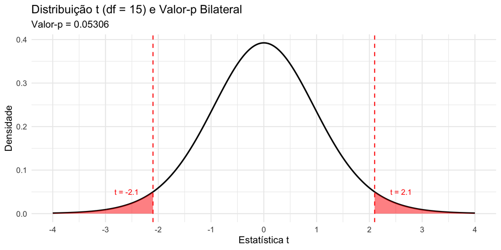

## Erros em Testes de Significância

**Amostragem e Erros**

- Por causa da variabilidade da amostragem, podemos cometer erros nas conclusões de um teste.
- Os dois erros potenciais são chamados de **Erro Tipo I** e **Erro Tipo II**.

## Erros em Testes de Significância

**Erro Tipo I ($\alpha$)**

- **Erro Tipo I**: Probabilidade de **rejeitar** $H_0$ quando **não** **deveríamos** rejeitar $H_0$, ou seja, quando ela é “verdadeira”.
- É um “**falso positivo**”: concluir que há um efeito ou diferença quando, na verdade, não há.
- $P(\text{Erro Tipo 1})$ = $\alpha$ = nível de significância do teste.
- Fixado na construção dos testes.
- Os níveis mais comuns são **0.01 (1%)**, **0.05 (5%)** e **0.10 (10%)**.

## Erros em Testes de Significância

**Erro Tipo II ($\beta$)**

- **Erro Tipo II**: Probabilidade de **não rejeitar** $H_0$ quando **deveria** rejeitar $H_0$.
- É um “**falso negativo**”: não detectar um efeito ou diferença quando ele realmente existe.
- $P(\text{Erro Tipo II})$ = $\beta$
- Erro Tipo II decresce na medida que
  - O Erro Tipo I aumenta
  - $n$ aumenta
  - o “verdadeiro” valor do parâmetro está mais distante do valor sob $H_0$.

## Erros em Testes de Significância

**Erro Tipo I e Erro Tipo II**

O quadro abaixo exibe as 4 decisões que podem ser tomadas em um teste de significância:

| Situação Real | Decisão Rejeitar H₀ | Decisão Não Rejeitar H₀ |
| --- | --- | --- |
| H₀ é “verdadeira” | Erro Tipo I (α) | Decisão Correta |
| H₀ é “falsa” | Decisão Correta | Erro Tipo II (β) |

## Erros em Testes de Significância

**Erro Tipo I e Erro Tipo II**

- **Não** se pode reduzir **simultaneamente** os dois tipos de erros.
- Na construção dos testes de significância, o erro tipo I é fixado com um valor suficientemente pequeno (1% ou 5% são os mais comuns), então determina-se um método de teste que minimiza o erro tipo II.

## Decisão em Testes de Significância

**Descrição**

- Um teste de significância clássico analisa se os dados contradizem $H_0$, ou não. As opções disponíveis para usar são:
  - **rejeitar** a hipótese nula ($H_0$)
  - **não rejeitar** a hipótese nula ($H_0$)
- Em testes de significância, usamos uma abordagem similar à **prova por contradição**: assumimos que $H_0$ é “verdadeira” e verificamos se os dados fornecem evidências suficientes para rejeitar essa hipótese.
- A **prova por contradição** é um método lógico em que se **assume o** **contrário** do que se quer provar e, através de uma série de deduções lógicas, se chega a uma contradição, provando assim que a suposição inicial estava errada.
- Se rejeitarmos $H_0$, esta rejeição nos leva a suportar a hipótese alternativa $H_A$ por meio de uma prova ou evidência indireta (contradição), mas não podemos afirmar diretamente que $H_A$ é “verdadeira”.
- $H_0$ é presumida como “verdadeira”. Sob essa presunção, se os dados observados forem muito improváveis, a evidência da amostra suporta $H_A$.

## Regra de Decisão com Valor-p

**Como Interpretar o Valor-p em Testes de Significância?**

**Objetivo:** Verificar se os dados fornecem evidência suficiente para rejeitar a hipótese nula ($H_0$), ou não.

#### Comparação entre Valor-p e o Nível de Significância

- **Se valor-p < 0,05:** **Rejeitamos** $H_0$
  - Evidência estatisticamente significativa
  - Resultado improvável se $H_0$ fosse verdadeira
- **Se valor-p ≥ 0,05:** **Não rejeitamos** $H_0$
  - Não há evidência suficiente contra a $H_0$
  - O resultado pode ser explicado pelo acaso

**Notas**:

- O nível de 0,05 é uma **convenção** — pode ser ajustado conforme o contexto (ex: 0,01 em pesquisas médicas críticas).
- O valor-p fornece o nível de significância **exato** do teste, ou seja, o menor nível de significância para o qual $H_0$ seria rejeitada.

## Exercício 1

**Enunciado**

- Uma rede de supermercados em Formiga seleciona periodicamente funcionários para receber treinamento em gestão.
- Um grupo de funcionárias afirmou recentemente que a empresa seleciona homens a uma taxa desproporcionalmente alta para este treinamento. A empresa negou essa alegação.
- Nos últimos anos, alegações semelhantes de discriminação contra as mulheres foram feitas sobre promoções e salários para mulheres que trabalham para várias empresas.
- Suponha que o grupo potencial de funcionários para treinamento em gestão seja grande e tenha 40% de homens e 60% de mulheres.
- A alegação da empresa de ausência de discriminação é uma hipótese de que, outras coisas sendo iguais, a cada escolha, a probabilidade de selecionar um homem é igual a 0,40 e a probabilidade de selecionar uma mulher é igual a 0,60.
- A alegação das mulheres é uma hipótese alternativa de que a probabilidade de selecionar um homem excede 0,40.
- Suponha que na última seleção de funcionários para treinamento em gestão, 9 dos 10 escolhidos eram homens. Nesse caso, podemos ficar inclinados a acreditar na alegação das mulheres.
- No entanto, devido à **variabilidade da amostragem**, mesmo se selecionados aleatoriamente do grupo de funcionários, não exatamente 40% dos escolhidos precisam ser homens, e talvez 9 homens de 10 escolhidos seja plausível ou provável.
- Para avaliar a questão estatisticamente, devemos analisar se esse resultado de seleção seria improvável, se não houvesse discriminação contra as mulheres, ou seja, se a alegação da empresa fosse verdadeira.
- Teste a alegação das mulheres.

## Solução do Exercício 1

**Há Evidência de discriminação?**

#### Formulação das Hipóteses

- As hipóteses do teste são:

$$\begin{cases}
H_0: p = 0.40 \\
H_A: p > 0.40
\end{cases}$$

#### Solucão em R

```r
n <- 10     # número total de funcionários selecionados
x <- 9      # número de homens selecionados
p0 <- 0.40  # proporção populacional sob a hipótese nula

# Teste de proporção
prop.test(x, n, p = p0, alternative = "greater", conf.level = 0.95)
```

```
    1-sample proportions test with continuity correction

data:  x out of n, null probability p0
X-squared = 8.44, df = 1, p-value = 0.0018
alternative hypothesis: true p is greater than 0.4
95 percent confidence interval:
 0.59463 1.00000
sample estimates:
  p
0.9
```

#### Conclusão

Como o valor-p é 0,002 e o nível de significância fixado foi 0,05, os dados fornecem evidência suficiente para rejeitar a hipótese nula. Isto é, podemos concluir que a alegação da empresa de que não há discriminação contra as mulheres na seleção de funcionários para a participação em programas de treinamento em gestão não é suportada pelos dados da amostra (valor-p = 0,002 < 0,05).

# A Crise dos Valores-p e da Significância Estatística na Ciência e em Finanças

## O que o valor-p *realmente* representa?

**Definição formal (Wasserstein e Lazar, 2016)**

“O valor-p é a probabilidade, assumindo a hipótese nula $H_0$ como verdadeira, de se obter um resultado **tão extremo ou mais extremo** do que o observado nos dados.”

#### Importante: o valor-p **não é**…

- A probabilidade de $H_0$ ser verdadeira
- Evidência de relevância prática  
  (ex.: valor-p < 0,05 com $\Delta$% retorno = 0,0001%)

## Abusos e distorções no uso do valor-p

**Práticas problemáticas e evidências empíricas**

[output not shown]

## Respostas institucionais ao problema

**Reações de revistas e instituições**

- (Wasserstein e Lazar, 2016): “Valores-p não devem ser usados isoladamente”
- (Harvey, 2017): Exigência de IC + efeito prático para publicação
- (Amrhein, Greenland e McShane, 2019): Recomendação de abandonar o termo “estatisticamente significativo”

#### Abordagens alternativas

- **Inferência Bayesiana**: Fator de Bayes (BF > 10) como evidência forte
- **Replicações sistemáticas**: (ex.: (Hou *et al.*, 2020) em finanças)

# Tamanho de Efeito

## O que é Tamanho do Efeito?

**Importância do tamanho do efeito**

- Quantifica a significância **prática** de um resultado: uma diferença de 0,05 p.p. na taxa de inadimplência **não** tem o mesmo impacto que uma diferença de 5 p.p.
- Entra diretamente no cálculo do **poder** estatístico: quanto maior o tamanho do efeito, menor a amostra necessária para detectar a diferença e vice-versa.
- É necessário em **meta‑análises**: permite a comparação e combinação de resultados de diferentes estudos, mesmo com escalas distintas.

## Significância Estatística vs. Relevância Prática

**Diferença entre Significância Estatística e Prática**

- O **valor‑p** representa a probabilidade de observarmos um resultado tão extremo quanto o obtido (ou mais), assumindo que a hipótese nula é verdadeira.
- Ele **não** mede a probabilidade de a hipótese nula ser verdadeira, e **não** fornece a magnitude do efeito observado.
- Um efeito de pequena magnitude pode produzir um valor‑p pequeno se a amostra for grande — e vice‑versa.
- Por outro lado, um efeito **economicamente relevante** pode não ser estatisticamente significativo em amostras pequenas.
- Por isso, deve‑se sempre relatar:
  - O **tamanho do efeito**
  - O respectivo **intervalo de confiança**
  - E, se necessário, o valor‑p — com a interpretação apropriada.

## Medidas Padronizadas Clássicas

**Medidas clássicas de tamanho do efeito**

| Contexto | Símbolo | Fórmula | Convenção* (Cohen) |
| --- | --- | --- | --- |
| Diferença de médias | $d$ | $d = \dfrac{\bar X_1 - \bar X_2}{s_{\text{pooled}}}$ | 0,2 = pequeno; 0,5 = médio; 0,8 = grande |
| Diferença de proporções | $h$ | $h = 2\arcsin\sqrt{p_1} - 2\arcsin\sqrt{p_2}$ | 0,2 / 0,5 / 0,8 |
| Regressão linear múltipla | $f^2$ | $f^2 = \dfrac{R^2_{\text{incl}} - R^2_{\text{base}}}{1 - R^2_{\text{incl}}}$ | 0,02 / 0,15 / 0,35 |

*: As convenções de Cohen (1988) são úteis como ponto de partida, **não como regras absolutas**.

## Diferença Absoluta vs. Diferença Padronizada

**Quando padronizar?**

- A **diferença absoluta** (ex: 0,45 p.p./mês) é intuitiva e útil.
- Mas ela não é comparável entre estudos ou contextos diferentes — depende da escala da variável.
- A **diferença padronizada** remove a unidade de medida e permite:
  - Comparações entre estudos
  - Cálculo do poder
  - Uso em meta-análises

**Resumo**:

- Use ambas quando possível.
- A diferença absoluta comunica **impacto econômico**.
- A padronizada facilita **inferência estatística**.

## Tamanho do Efeito em Finanças

**Medidas por Subárea**

| Área | Métrica | Interpretação |
| --- | --- | --- |
| Precificação de Ativos | $\alpha$ (pb/mês) | > 50 bps/mês = economicamente relevante |
| Finanças Corporativas | $R^2$ do modelo | > 10% = ajuste relativamente elevado¹ |
| Economia Comportamental | $d$ de Cohen | 0,2 = pequeno; 0,5 = médio; 0,8 = grande |

**Nota**:

- pb = pontos-base. 1 pb = 0,01%, então 50 bps = 0,5%.

## Exercício

**Teste de hipótese entre duas médias**

Um estudo experimental (Barber e Odean, 2001) analisou o retorno mensal obtido por dois grupos de participantes, classificados com base em um questionário de autoconfiança financeira:

- Grupo controle (sem excesso de confiança): 120 observações com retorno médio populacional de 0,9% ao mês; desvio padrão de 0,35%
- Grupo com excesso de confiança: 120 observações com retorno médio populacional de 0,3% ao mês; desvio padrão de 0,38%
- Simulando os retornos obtidos pelos grupos:

```r
# fixa a semente para reprodutibilidade
set.seed(42)

# Simula os retornos mensais para os dois grupos
sem_excesso <- rnorm(120, mean = 0.009, sd = 0.0035)
com_excesso <- rnorm(120, mean = 0.003, sd = 0.0038)
```

#### Questões:

1. Formule as **hipóteses nula e alternativa** para comparar as médias dos dois grupos.
2. Realize um **teste t para duas amostras independentes** assumindo variâncias diferentes. Apresente o valor-p, a estatística t e o intervalo de confiança da diferença de médias.
3. Calcule a diferença média pontual e interprete-a em termos mensais e anualizados.
4. O resultado é estatisticamente significativo ao nível de 5%?
5. A diferença observada é economicamente relevante?
6. Calcule e interprete o tamanho do efeito (d de Cohen) com base na diferença de médias padronizada.

## Solução do Exercício 2

**Resolução**

#### 1. Hipóteses

Sendo $\mu_1$ os retornos médios do grupo com excesso de confiança e $\mu_2$ os retornos médios do grupo sem excesso de confiança, as hipóteses são:

$$\begin{cases}
H_0 : \mu_1 = \mu_2 \\
H_A : \mu_1 \neq \mu_2
\end{cases}$$

#### 2. Teste t de Student (Welch)

```r
resultado_t <- t.test(com_excesso, sem_excesso)
resultado_t
```

```
    Welch Two Sample t-test

data:  com_excesso and sem_excesso
t = -14.4, df = 237, p-value <0.0000000000000002
alternative hypothesis: true difference in means is not equal to 0
95 percent confidence interval:
 -0.0074023 -0.0056176
sample estimates:
mean of x mean of y
0.0025938 0.0091038
```

#### 3. Diferença média observada

```r
mean(sem_excesso) - mean(com_excesso)
```

```
[1] 0.0065099
```

#### 6. Tamanho do efeito: d de Cohen

```r
library(effectsize)

# Calcula o d de Cohen
cohens_d(com_excesso, sem_excesso)
```

```
Cohen's d |         95% CI
--------------------------
-1.86     | [-2.16, -1.55]

- Estimated using pooled SD.
```

#### Conclusão

# Poder e Tamanho da Amostra

## Conceito de poder estatístico

**Definição**

$$\text{Poder} = P(\text{Rejeitar}\,\, H_0 \mid H_0\,\,\text{falsa}) = 1 - \beta$$

- Mede a probabilidade de **detectar um efeito real**.
- Depende de cinco fatores principais:
  - tamanho da amostra
  - variabilidade da variável
  - tamanho do efeito
  - nível de significância
  - tipo de teste (unilateral ou bilateral)
- Em geral, recomenda-se poder maior ou igual a 0,80 (80%).

## Relação entre $\alpha$ e $\beta$

**Trade-off entre erro tipo I e tipo II**

Quando o tamanho amostral é fixo:

- Reduzir $\alpha$ tende a aumentar $\beta$, diminuindo o poder.
- Aumentar o poder requer aumentar $n$, ou aceitar um $\alpha$ mais alto.

## Cálculo aproximado do tamanho da amostra

**Fórmula e interpretação**

$$n \approx \left( \frac{z_{1 - \alpha} + z_{1 - \beta}}{\delta / \sigma} \right)^2$$

Onde:

- $\delta$: efeito mínimo relevante (diferença absoluta entre grupos)
- $\sigma$: desvio padrão (estimado ou conhecido)
- $z_{1 - \alpha}$: quantil da normal padrão correspondente ao nível de significância
- $z_{1 - \beta}$: quantil da normal padrão correspondente ao poder desejado

Essa fórmula fornece uma estimativa inicial do tamanho da amostra necessário em testes simples sob condições ideais.

## Derivação da fórmula

**Visão Geral**

Considere o teste de hipóteses para a diferença entre duas médias, com variância conhecida:

$$H_0: \mu_1 = \mu_2 \quad \text{vs} \quad H_1: \mu_1 \ne \mu_2$$

A estatística do teste sob $H_0$ é:

$$Z = \frac{(\mu_1 - \mu_2)}{\sigma / \sqrt{n}} \sim N(0,1)$$

Queremos que a diferença mínima detectável $\delta$ seja suficientemente grande para ser identificada com poder $1 - \beta$. Isso ocorre quando:

$$\frac{\delta}{\sigma / \sqrt{n}} \ge z_{1 - \alpha} + z_{1 - \beta}$$

Isolando $n$:

$$n \ge \left( \frac{z_{1 - \alpha} + z_{1 - \beta}}{\delta / \sigma} \right)^2$$

Esta é a fórmula usada como aproximação em testes normais com variância constante.

## Quando a fórmula não é suficiente

**Modelos mais realistas exigem simulação**

A fórmula anterior **assume**:

- distribuição normal
- variâncias conhecidas e constantes
- amostras independentes
- nenhuma covariável ou estrutura de dependência

Na prática, muitos estudos em finanças envolvem **modelos mais complexos**, como:

- **Modelos não lineares**:
  - **Logit** e **Probit**: usados para prever inadimplência, aprovação de crédito, adesão a políticas
  - A variância dos erros **não é constante** e o efeito não é linear
- **Modelos com dados em painel**:
  - **Efeitos fixos**: usados para controlar heterogeneidade inobservável entre empresas ao longo do tempo
  - A presença de **dependência temporal** viola suposições da fórmula
- **Modelos dinâmicos**:
  - Ex: **Arellano-Bond GMM**, usado para investigar ajustes parciais de alavancagem, payout, etc.
  - O número efetivo de observações depende de lags e estrutura de instrumentos
- **Modelos com variáveis instrumentais**:
  - Quando há endogeneidade, a variância dos estimadores pode ser **muito maior** do que o esperado
  - A simples aplicação da fórmula superestima o poder

Conclusão:

- Para esses casos, o tamanho da amostra necessário não pode ser estimado com fórmulas analíticas.
- O mais recomendado é usar simulação de Monte Carlo.

## Por que usar simulação?

**Vantagens**

Simular o poder de um teste estatístico significa:

1. Definir o modelo teórico (ex: painel com efeitos fixos)
2. Gerar dados simulados com diferentes tamanhos de amostra
3. Estimar o modelo várias vezes (ex: 1000 repetições)
4. Calcular a proporção de testes que rejeitam $H_0$

Isso permite:

- Incorporar estrutura realista dos dados (painel, heterocedasticidade, lags)
- Avaliar o impacto de violações das suposições clássicas
- Calcular o poder de testes que não têm distribuição amostral exata, etc.

## Cenário

**Motivação**

- Em estudos experimentais reais, não se conhece a média e o desvio padrão populacional
- Por isso, utilizamos estimativas obtidas em um estudo piloto, pré-teste ou estudo publicado
- Vamos considerar o estudo clássico de Barber e Odean (2001), que avaliou se investidores com excesso de confiança obtêm retornos inferiores

Resumo de dados do estudo:

| Grupo | Retorno médio amostral | Desvio padrão amostral | n |
| --- | --- | --- | --- |
| Sem excesso de confiança | 0,9% ao mês | 3,5% | 120 |
| Com excesso de confiança | 0,3% ao mês | 3,8% | 120 |

Nosso objetivo é usar essas estimativas para calcular o tamanho necessário para replicar o estudo com 80% de poder e $\alpha = 0,05$.

## Estimando o tamanho de efeito

**d de Cohen estimado a partir de dados amostrais**

```r
# Dados amostrais do estudo anterior
m1 <- 0.009; sd1 <- 0.035
m2 <- 0.003; sd2 <- 0.038

# Cohen's d com variâncias desiguais
s_agrupado <- sqrt((sd1^2 + sd2^2)/2)
d_est <- (m1 - m2) / s_agrupado
round(d_est, 3)
```

```
[1] 0.164
```

Resultado:

- Estimativa de $d$ = 0,164

Essa estimativa será usada como entrada para o cálculo do tamanho da amostra.

## Cálculo de n

**Utilizando `pwr.t.test()`**

```r
library(pwr)

pwr.t.test(d = d_est,
           sig.level = 0.05,
           power = 0.80,
           type = "two.sample",
           alternative = "two.sided")
```

```
     Two-sample t test power calculation

              n = 582.87
              d = 0.16424
      sig.level = 0.05
          power = 0.8
    alternative = two.sided

NOTE: n is number in *each* group
```

Resultado:

- d estimado $\approx$ 0,164
- Tamanho necessário por grupo: $\approx$ 583 participantes

Interpretação:

- Para detectar um efeito semelhante ao observado no estudo anterior com 80% de poder, seriam necessários 583 participantes por grupo

## Conclusão

**Considerações finais**

- É **inadequado** usar valores populacionais hipotéticos para estimar tamanho amostral
- O correto é usar:
  - **Estudos anteriores**
  - **Estudos piloto**
  - **Meta-análises**, se disponíveis
- O efeito observado no estudo de Barber e Odean (2001) é pequeno ($d ≈ 0,16$), mas economicamente relevante
- Com essa magnitude de efeito, estudos precisam de n > 580 por grupo para obter um poder adequado.

# Resumo

## Fluxo completo de um teste

**Etapas**

1. **Definir** questão substantiva e parâmetros populacionais ($\mu$, proporção, coeficiente).
2. **Escolher** medida de efeito relevante ($d$, $h$, $\beta$, etc.).
3. **Planejar $n$** com análise de poder (antes de coletar dados).
4. **Coletar** dados adequadamente
5. **Explorar** dados e verificar suposições.
6. **Calcular** $\hat \theta$, IC, valor‑p **e** tamanho de efeito.
7. **Interpretar** conjuntamente (estatística + contexto).

## Referências

AMRHEIN, V.; GREENLAND, S.; MCSHANE, B. [Scientists Rise Up Against Statistical Significance](https://doi.org/10.1038/d41586-019-00857-9). **Nature**, v. 567, p. 305–307, 2019.

BARBER, B. M.; ODEAN, T. [Boys Will Be Boys: Gender, Overconfidence, and Common Stock Investment](https://doi.org/10.1162/003355301556400). **The Quarterly Journal of Economics**, v. 116, n. 1, p. 261–292, 2001.

BRODEUR, A. *et al.* [Star Wars: The Empirics Strike Back](https://doi.org/10.1257/app.20150044). **American Economic Journal: Applied Economics**, v. 8, n. 1, p. 1–32, 2016.

FANELLI, D. [Negative Results Are Disappearing from Most Disciplines and Countries](https://doi.org/10.1007/s11192-011-0494-7). **Scientometrics**, v. 90, n. 3, p. 891–904, 2012.

HARVEY, C. R. [Presidential address: The scientific outlook in financial economics](https://doi.org/10.1111/jofi.12530). **The Journal of Finance**, v. 72, n. 4, p. 1399–1440, 2017.

HEAD, M. L. *et al.* [The Extent and Consequences of P-Hacking in Science](https://doi.org/10.1371/journal.pbio.1002106). **PLoS Biology**, v. 13, n. 3, p. e1002106, 2015.

HOU, K. *et al.* [Replicating Anomalies](https://doi.org/10.1093/rfs/hhy131). **Review of Financial Studies**, v. 33, n. 5, p. 2019–2063, 2020.

IOANNIDIS, J. P. A. [Why Most Published Research Findings Are False](https://doi.org/10.1371/journal.pmed.0020124). **PLoS Medicine**, v. 2, n. 8, p. e124, 2005.

WASSERSTEIN, R. L.; LAZAR, N. A. [American Statistical Association Statement on Statistical Significance and P-Values](https://doi.org/10.1080/00031305.2016.1154108). **The American Statistician**, v. 70, n. 2, p. 129–133, 2016.

## Atualizando os Repositórios

**Instruções**

1. No terminal do RStudio, verifique quais arquivos/pastas foram modificados ou criados com:

```bash
git status
```

2. Você pode adicionar todos os arquivos de uma vez com:

```bash
git add .
```

3. Execute git status novamente para confirmar que todos os arquivos foram adicionados (aparecerão em verde sob “*Changes to be committed*”):

```bash
git status
```

4. Se tudo estiver em verde, faça um commit com uma mensagem descritiva:

```bash
git commit -m "atualizacoes aula 14"
```

5. Se algum arquivo ou pasta ainda aparecer em vermelho após o segundo git status, adicione as pastas/arquivos um por um:

```bash
git add relatorios/11-relatorio/11-relatorio.qmd
```

6. Execute git status novamente e faça o commit quando todos os arquivos estiverem em verde:

```bash
git commit -m "atualizacoes aula 14"
```

7. Envie o repositório local atualizado para o GitHub:

```bash
git push origin main
```